# Risk Factor Analysis

## Outcome Variable

**Outcome Variable:** ever_sstunted

## Predictor Variables

**Intervention Variable:** mwtkg

**Adjustment Set:**

- arm
- W_mage
- meducyrs
- feducyrs
- hhwealth_quart
- W_nchldlt5
- brthmon
- W_parity
- delta_W_mage
- delta_meducyrs
- delta_feducyrs
- delta_hhwealth_quart
- delta_W_nchldlt5
- delta_brthmon
- delta_W_parity

## Stratifying Variables

The analysis was stratified on these variable(s):

- agecat
- studyid
- country

## Data Summary

| agecat | studyid | country | mwtkg | ever_sstunted | n_cell | n |
| --- | --- | --- | --- | --- | --- | --- |
| 0-24 months | iLiNS-Zinc | BURKINA FASO | >=58 kg | 0 | 871 | 3216 |
| 0-24 months | iLiNS-Zinc | BURKINA FASO | >=58 kg | 1 | 66 | 3216 |
| 0-24 months | iLiNS-Zinc | BURKINA FASO | <52 kg | 0 | 1032 | 3216 |
| 0-24 months | iLiNS-Zinc | BURKINA FASO | <52 kg | 1 | 169 | 3216 |
| 0-24 months | iLiNS-Zinc | BURKINA FASO | [52-58) kg | 0 | 975 | 3216 |
| 0-24 months | iLiNS-Zinc | BURKINA FASO | [52-58) kg | 1 | 103 | 3216 |
| 0-24 months | JiVitA-3 | BANGLADESH | >=58 kg | 0 | 575 | 27196 |
| 0-24 months | JiVitA-3 | BANGLADESH | >=58 kg | 1 | 94 | 27196 |
| 0-24 months | JiVitA-3 | BANGLADESH | <52 kg | 0 | 20106 | 27196 |
| 0-24 months | JiVitA-3 | BANGLADESH | <52 kg | 1 | 4647 | 27196 |
| 0-24 months | JiVitA-3 | BANGLADESH | [52-58) kg | 0 | 1498 | 27196 |
| 0-24 months | JiVitA-3 | BANGLADESH | [52-58) kg | 1 | 276 | 27196 |
| 0-24 months | LCNI-5 | MALAWI | >=58 kg | 0 | 102 | 838 |
| 0-24 months | LCNI-5 | MALAWI | >=58 kg | 1 | 12 | 838 |
| 0-24 months | LCNI-5 | MALAWI | <52 kg | 0 | 370 | 838 |
| 0-24 months | LCNI-5 | MALAWI | <52 kg | 1 | 134 | 838 |
| 0-24 months | LCNI-5 | MALAWI | [52-58) kg | 0 | 189 | 838 |
| 0-24 months | LCNI-5 | MALAWI | [52-58) kg | 1 | 31 | 838 |
| 0-24 months | MAL-ED | BANGLADESH | >=58 kg | 0 | 45 | 254 |
| 0-24 months | MAL-ED | BANGLADESH | >=58 kg | 1 | 3 | 254 |
| 0-24 months | MAL-ED | BANGLADESH | <52 kg | 0 | 113 | 254 |
| 0-24 months | MAL-ED | BANGLADESH | <52 kg | 1 | 49 | 254 |
| 0-24 months | MAL-ED | BANGLADESH | [52-58) kg | 0 | 40 | 254 |
| 0-24 months | MAL-ED | BANGLADESH | [52-58) kg | 1 | 4 | 254 |
| 0-24 months | MAL-ED | BRAZIL | >=58 kg | 0 | 132 | 221 |
| 0-24 months | MAL-ED | BRAZIL | >=58 kg | 1 | 11 | 221 |
| 0-24 months | MAL-ED | BRAZIL | <52 kg | 0 | 38 | 221 |
| 0-24 months | MAL-ED | BRAZIL | <52 kg | 1 | 4 | 221 |
| 0-24 months | MAL-ED | BRAZIL | [52-58) kg | 0 | 30 | 221 |
| 0-24 months | MAL-ED | BRAZIL | [52-58) kg | 1 | 6 | 221 |

[output cut: 72 more lines]

The following strata were considered:

- agecat: 0-24 months, studyid: iLiNS-Zinc, country: BURKINA FASO
- agecat: 0-24 months, studyid: JiVitA-3, country: BANGLADESH
- agecat: 0-24 months, studyid: LCNI-5, country: MALAWI
- agecat: 0-24 months, studyid: MAL-ED, country: BANGLADESH
- agecat: 0-24 months, studyid: MAL-ED, country: BRAZIL
- agecat: 0-24 months, studyid: MAL-ED, country: INDIA
- agecat: 0-24 months, studyid: MAL-ED, country: NEPAL
- agecat: 0-24 months, studyid: MAL-ED, country: PERU
- agecat: 0-24 months, studyid: MAL-ED, country: SOUTH AFRICA
- agecat: 0-24 months, studyid: MAL-ED, country: TANZANIA, UNITED REPUBLIC OF
- agecat: 0-24 months, studyid: NIH-Birth, country: BANGLADESH
- agecat: 0-24 months, studyid: NIH-Crypto, country: BANGLADESH
- agecat: 0-24 months, studyid: PROBIT, country: BELARUS
- agecat: 0-24 months, studyid: PROVIDE, country: BANGLADESH
- agecat: 0-24 months, studyid: SAS-CompFeed, country: INDIA
- agecat: 0-24 months, studyid: TanzaniaChild2, country: TANZANIA, UNITED REPUBLIC OF
- agecat: 0-24 months, studyid: ZVITAMBO, country: ZIMBABWE

### Dropped Strata

Some strata were dropped due to rare outcomes:

- agecat: 0-24 months, studyid: MAL-ED, country: BANGLADESH
- agecat: 0-24 months, studyid: MAL-ED, country: BRAZIL
- agecat: 0-24 months, studyid: MAL-ED, country: NEPAL

## Methods Detail

We're interested in the causal parameters $E[Y_a]$ for all values of $a \in \mathcal{A}$. These parameters represent the mean outcome if, possibly contrary to fact, we intervened to set all units to have $A=a$. Under the randomization and positivity assumptions, these are identified by the statistical parameters $\psi_a=E_W[E_{Y|A,W}(Y|A=a,W)]$. In addition, we're interested in the mean of $Y$, $E[Y]$ under no intervention (the observed mean). We will estimate these parameters by using SuperLearner to fit the relevant likelihood factors -- $E_{Y|A,W}(Y|A=a,W)$ and $p(A=a|W)$, and then updating our likelihood fit using a joint TMLE.

For unadjusted analyses ($W=\{\}$), initial likelihoods were estimated using Lrnr_glm to estimate the simple $E(Y|A)$ and Lrnr_mean to estimate $p(A)$. For adjusted analyses, a small library containing Lrnr_glmnet, Lrnr_xgboost, and Lrnr_mean was used.

Having estimated these parameters, we will then use the delta method to estimate relative risks and attributable risks relative to a prespecified baseline level of $A$.

# Results Detail

## Results Plots

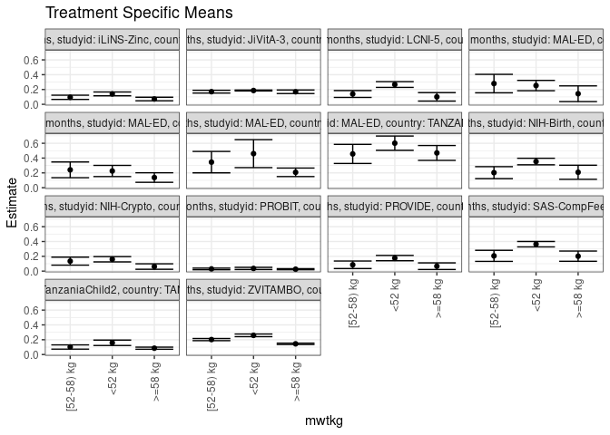

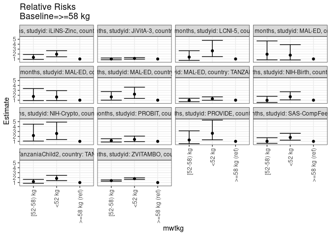

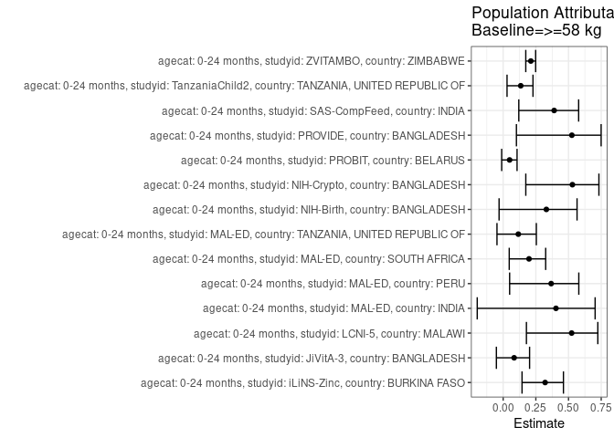

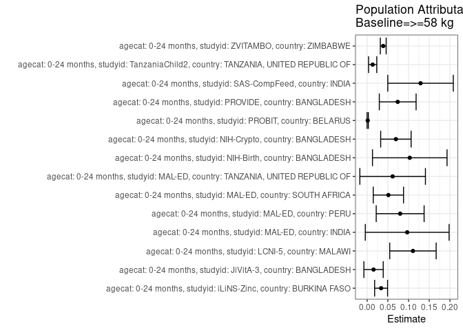

## Results Table

### Parameter: TSM

| agecat | studyid | country | intervention_level | baseline_level | estimate | ci_lower | ci_upper |
| --- | --- | --- | --- | --- | --- | --- | --- |
| 0-24 months | iLiNS-Zinc | BURKINA FASO | >=58 kg | NA | 0.0713597 | 0.0471043 | 0.0956150 |
| 0-24 months | iLiNS-Zinc | BURKINA FASO | <52 kg | NA | 0.1404515 | 0.1145690 | 0.1663340 |
| 0-24 months | iLiNS-Zinc | BURKINA FASO | [52-58) kg | NA | 0.0947113 | 0.0661093 | 0.1233133 |
| 0-24 months | JiVitA-3 | BANGLADESH | >=58 kg | NA | 0.1689859 | 0.1450359 | 0.1929358 |
| 0-24 months | JiVitA-3 | BANGLADESH | <52 kg | NA | 0.1863150 | 0.1805006 | 0.1921294 |
| 0-24 months | JiVitA-3 | BANGLADESH | [52-58) kg | NA | 0.1703063 | 0.1516006 | 0.1890120 |
| 0-24 months | LCNI-5 | MALAWI | >=58 kg | NA | 0.1005729 | 0.0434905 | 0.1576553 |
| 0-24 months | LCNI-5 | MALAWI | <52 kg | NA | 0.2670721 | 0.2284696 | 0.3056746 |
| 0-24 months | LCNI-5 | MALAWI | [52-58) kg | NA | 0.1392915 | 0.0930392 | 0.1855438 |
| 0-24 months | MAL-ED | INDIA | >=58 kg | NA | 0.1428571 | 0.0368097 | 0.2489046 |
| 0-24 months | MAL-ED | INDIA | <52 kg | NA | 0.2533333 | 0.1835886 | 0.3230780 |
| 0-24 months | MAL-ED | INDIA | [52-58) kg | NA | 0.2800000 | 0.1552882 | 0.4047118 |
| 0-24 months | MAL-ED | PERU | >=58 kg | NA | 0.1374666 | 0.0728316 | 0.2021016 |
| 0-24 months | MAL-ED | PERU | <52 kg | NA | 0.2260693 | 0.1506489 | 0.3014898 |
| 0-24 months | MAL-ED | PERU | [52-58) kg | NA | 0.2413613 | 0.1351336 | 0.3475890 |
| 0-24 months | MAL-ED | SOUTH AFRICA | >=58 kg | NA | 0.2079437 | 0.1504443 | 0.2654431 |
| 0-24 months | MAL-ED | SOUTH AFRICA | <52 kg | NA | 0.4599042 | 0.2709423 | 0.6488661 |
| 0-24 months | MAL-ED | SOUTH AFRICA | [52-58) kg | NA | 0.3451404 | 0.2006480 | 0.4896328 |
| 0-24 months | MAL-ED | TANZANIA, UNITED REPUBLIC OF | >=58 kg | NA | 0.4696253 | 0.3691989 | 0.5700517 |
| 0-24 months | MAL-ED | TANZANIA, UNITED REPUBLIC OF | <52 kg | NA | 0.6013577 | 0.5050337 | 0.6976817 |
| 0-24 months | MAL-ED | TANZANIA, UNITED REPUBLIC OF | [52-58) kg | NA | 0.4562370 | 0.3272265 | 0.5852476 |
| 0-24 months | NIH-Birth | BANGLADESH | >=58 kg | NA | 0.2086370 | 0.1137905 | 0.3034836 |
| 0-24 months | NIH-Birth | BANGLADESH | <52 kg | NA | 0.3532396 | 0.3090393 | 0.3974399 |
| 0-24 months | NIH-Birth | BANGLADESH | [52-58) kg | NA | 0.2032388 | 0.1224132 | 0.2840644 |
| 0-24 months | NIH-Crypto | BANGLADESH | >=58 kg | NA | 0.0616700 | 0.0248176 | 0.0985223 |
| 0-24 months | NIH-Crypto | BANGLADESH | <52 kg | NA | 0.1600967 | 0.1244616 | 0.1957317 |
| 0-24 months | NIH-Crypto | BANGLADESH | [52-58) kg | NA | 0.1347465 | 0.0805556 | 0.1889373 |
| 0-24 months | PROBIT | BELARUS | >=58 kg | NA | 0.0259550 | 0.0185615 | 0.0333485 |
| 0-24 months | PROBIT | BELARUS | <52 kg | NA | 0.0362818 | 0.0216449 | 0.0509186 |
| 0-24 months | PROBIT | BELARUS | [52-58) kg | NA | 0.0299464 | 0.0191808 | 0.0407119 |
| 0-24 months | PROVIDE | BANGLADESH | >=58 kg | NA | 0.0666667 | 0.0220029 | 0.1113304 |
| 0-24 months | PROVIDE | BANGLADESH | <52 kg | NA | 0.1759259 | 0.1399941 | 0.2118577 |
| 0-24 months | PROVIDE | BANGLADESH | [52-58) kg | NA | 0.0854701 | 0.0347726 | 0.1361675 |
| 0-24 months | SAS-CompFeed | INDIA | >=58 kg | NA | 0.2016896 | 0.1326257 | 0.2707535 |
| 0-24 months | SAS-CompFeed | INDIA | <52 kg | NA | 0.3636297 | 0.3271629 | 0.4000964 |
| 0-24 months | SAS-CompFeed | INDIA | [52-58) kg | NA | 0.2061081 | 0.1311438 | 0.2810724 |
| 0-24 months | TanzaniaChild2 | TANZANIA, UNITED REPUBLIC OF | >=58 kg | NA | 0.0857282 | 0.0712952 | 0.1001612 |
| 0-24 months | TanzaniaChild2 | TANZANIA, UNITED REPUBLIC OF | <52 kg | NA | 0.1585610 | 0.1219129 | 0.1952090 |
| 0-24 months | TanzaniaChild2 | TANZANIA, UNITED REPUBLIC OF | [52-58) kg | NA | 0.1016331 | 0.0731761 | 0.1300901 |
| 0-24 months | ZVITAMBO | ZIMBABWE | >=58 kg | NA | 0.1447161 | 0.1355923 | 0.1538398 |
| 0-24 months | ZVITAMBO | ZIMBABWE | <52 kg | NA | 0.2591148 | 0.2411070 | 0.2771225 |
| 0-24 months | ZVITAMBO | ZIMBABWE | [52-58) kg | NA | 0.2020359 | 0.1872701 | 0.2168017 |

### Parameter: E(Y)

| agecat | studyid | country | intervention_level | baseline_level | estimate | ci_lower | ci_upper |
| --- | --- | --- | --- | --- | --- | --- | --- |
| 0-24 months | iLiNS-Zinc | BURKINA FASO | NA | NA | 0.1050995 | 0.0855497 | 0.1246493 |
| 0-24 months | JiVitA-3 | BANGLADESH | NA | NA | 0.1844757 | 0.1788759 | 0.1900754 |
| 0-24 months | LCNI-5 | MALAWI | NA | NA | 0.2112172 | 0.1835650 | 0.2388693 |
| 0-24 months | MAL-ED | INDIA | NA | NA | 0.2396694 | 0.1857746 | 0.2935643 |
| 0-24 months | MAL-ED | PERU | NA | NA | 0.2172414 | 0.1696986 | 0.2647841 |
| 0-24 months | MAL-ED | SOUTH AFRICA | NA | NA | 0.2592593 | 0.2068905 | 0.3116280 |
| 0-24 months | MAL-ED | TANZANIA, UNITED REPUBLIC OF | NA | NA | 0.5312500 | 0.4700011 | 0.5924989 |
| 0-24 months | NIH-Birth | BANGLADESH | NA | NA | 0.3116057 | 0.2753823 | 0.3478292 |
| 0-24 months | NIH-Crypto | BANGLADESH | NA | NA | 0.1311258 | 0.1070332 | 0.1552185 |
| 0-24 months | PROBIT | BELARUS | NA | NA | 0.0273018 | 0.0201306 | 0.0344729 |
| 0-24 months | PROVIDE | BANGLADESH | NA | NA | 0.1405082 | 0.1141551 | 0.1668613 |
| 0-24 months | SAS-CompFeed | INDIA | NA | NA | 0.3306931 | 0.3017014 | 0.3596847 |
| 0-24 months | TanzaniaChild2 | TANZANIA, UNITED REPUBLIC OF | NA | NA | 0.0990646 | 0.0869885 | 0.1111408 |
| 0-24 months | ZVITAMBO | ZIMBABWE | NA | NA | 0.1835951 | 0.1764261 | 0.1907642 |

### Parameter: RR

| agecat | studyid | country | intervention_level | baseline_level | estimate | ci_lower | ci_upper |
| --- | --- | --- | --- | --- | --- | --- | --- |
| 0-24 months | iLiNS-Zinc | BURKINA FASO | >=58 kg | >=58 kg | 1.0000000 | 1.0000000 | 1.000000 |
| 0-24 months | iLiNS-Zinc | BURKINA FASO | <52 kg | >=58 kg | 1.9682201 | 1.4408114 | 2.688687 |
| 0-24 months | iLiNS-Zinc | BURKINA FASO | [52-58) kg | >=58 kg | 1.3272387 | 0.9166779 | 1.921681 |
| 0-24 months | JiVitA-3 | BANGLADESH | >=58 kg | >=58 kg | 1.0000000 | 1.0000000 | 1.000000 |
| 0-24 months | JiVitA-3 | BANGLADESH | <52 kg | >=58 kg | 1.1025479 | 0.9568936 | 1.270373 |
| 0-24 months | JiVitA-3 | BANGLADESH | [52-58) kg | >=58 kg | 1.0078138 | 0.8429743 | 1.204887 |
| 0-24 months | LCNI-5 | MALAWI | >=58 kg | >=58 kg | 1.0000000 | 1.0000000 | 1.000000 |
| 0-24 months | LCNI-5 | MALAWI | <52 kg | >=58 kg | 2.6555089 | 1.4785038 | 4.769502 |
| 0-24 months | LCNI-5 | MALAWI | [52-58) kg | >=58 kg | 1.3849807 | 0.7173544 | 2.673952 |
| 0-24 months | MAL-ED | INDIA | >=58 kg | >=58 kg | 1.0000000 | 1.0000000 | 1.000000 |
| 0-24 months | MAL-ED | INDIA | <52 kg | >=58 kg | 1.7733333 | 0.8034193 | 3.914159 |
| 0-24 months | MAL-ED | INDIA | [52-58) kg | >=58 kg | 1.9600000 | 0.8246831 | 4.658274 |
| 0-24 months | MAL-ED | PERU | >=58 kg | >=58 kg | 1.0000000 | 1.0000000 | 1.000000 |
| 0-24 months | MAL-ED | PERU | <52 kg | >=58 kg | 1.6445406 | 0.9219922 | 2.933337 |
| 0-24 months | MAL-ED | PERU | [52-58) kg | >=58 kg | 1.7557821 | 0.9189230 | 3.354765 |
| 0-24 months | MAL-ED | SOUTH AFRICA | >=58 kg | >=58 kg | 1.0000000 | 1.0000000 | 1.000000 |
| 0-24 months | MAL-ED | SOUTH AFRICA | <52 kg | >=58 kg | 2.2116766 | 1.3468752 | 3.631749 |
| 0-24 months | MAL-ED | SOUTH AFRICA | [52-58) kg | >=58 kg | 1.6597781 | 1.0049407 | 2.741319 |
| 0-24 months | MAL-ED | TANZANIA, UNITED REPUBLIC OF | >=58 kg | >=58 kg | 1.0000000 | 1.0000000 | 1.000000 |
| 0-24 months | MAL-ED | TANZANIA, UNITED REPUBLIC OF | <52 kg | >=58 kg | 1.2805053 | 0.9803132 | 1.672622 |
| 0-24 months | MAL-ED | TANZANIA, UNITED REPUBLIC OF | [52-58) kg | >=58 kg | 0.9714915 | 0.6808347 | 1.386233 |
| 0-24 months | NIH-Birth | BANGLADESH | >=58 kg | >=58 kg | 1.0000000 | 1.0000000 | 1.000000 |
| 0-24 months | NIH-Birth | BANGLADESH | <52 kg | >=58 kg | 1.6930822 | 1.0564861 | 2.713265 |
| 0-24 months | NIH-Birth | BANGLADESH | [52-58) kg | >=58 kg | 0.9741263 | 0.5326902 | 1.781377 |
| 0-24 months | NIH-Crypto | BANGLADESH | >=58 kg | >=58 kg | 1.0000000 | 1.0000000 | 1.000000 |
| 0-24 months | NIH-Crypto | BANGLADESH | <52 kg | >=58 kg | 2.5960234 | 1.3733891 | 4.907085 |
| 0-24 months | NIH-Crypto | BANGLADESH | [52-58) kg | >=58 kg | 2.1849608 | 1.0631957 | 4.490287 |
| 0-24 months | PROBIT | BELARUS | >=58 kg | >=58 kg | 1.0000000 | 1.0000000 | 1.000000 |
| 0-24 months | PROBIT | BELARUS | <52 kg | >=58 kg | 1.3978713 | 0.9466159 | 2.064242 |
| 0-24 months | PROBIT | BELARUS | [52-58) kg | >=58 kg | 1.1537798 | 0.8715652 | 1.527376 |
| 0-24 months | PROVIDE | BANGLADESH | >=58 kg | >=58 kg | 1.0000000 | 1.0000000 | 1.000000 |
| 0-24 months | PROVIDE | BANGLADESH | <52 kg | >=58 kg | 2.6388889 | 1.3099126 | 5.316183 |
| 0-24 months | PROVIDE | BANGLADESH | [52-58) kg | >=58 kg | 1.2820513 | 0.5239569 | 3.137005 |
| 0-24 months | SAS-CompFeed | INDIA | >=58 kg | >=58 kg | 1.0000000 | 1.0000000 | 1.000000 |
| 0-24 months | SAS-CompFeed | INDIA | <52 kg | >=58 kg | 1.8029177 | 1.2366372 | 2.628509 |
| 0-24 months | SAS-CompFeed | INDIA | [52-58) kg | >=58 kg | 1.0219077 | 0.6001578 | 1.740035 |
| 0-24 months | TanzaniaChild2 | TANZANIA, UNITED REPUBLIC OF | >=58 kg | >=58 kg | 1.0000000 | 1.0000000 | 1.000000 |
| 0-24 months | TanzaniaChild2 | TANZANIA, UNITED REPUBLIC OF | <52 kg | >=58 kg | 1.8495780 | 1.3892255 | 2.462479 |
| 0-24 months | TanzaniaChild2 | TANZANIA, UNITED REPUBLIC OF | [52-58) kg | >=58 kg | 1.1855271 | 0.8550220 | 1.643788 |
| 0-24 months | ZVITAMBO | ZIMBABWE | >=58 kg | >=58 kg | 1.0000000 | 1.0000000 | 1.000000 |
| 0-24 months | ZVITAMBO | ZIMBABWE | <52 kg | >=58 kg | 1.7905045 | 1.6302292 | 1.966537 |
| 0-24 months | ZVITAMBO | ZIMBABWE | [52-58) kg | >=58 kg | 1.3960848 | 1.2677534 | 1.537407 |

### Parameter: PAR

| agecat | studyid | country | intervention_level | baseline_level | estimate | ci_lower | ci_upper |
| --- | --- | --- | --- | --- | --- | --- | --- |
| 0-24 months | iLiNS-Zinc | BURKINA FASO | >=58 kg | NA | 0.0337398 | 0.0180756 | 0.0494041 |
| 0-24 months | JiVitA-3 | BANGLADESH | >=58 kg | NA | 0.0154898 | -0.0078571 | 0.0388367 |
| 0-24 months | LCNI-5 | MALAWI | >=58 kg | NA | 0.1106443 | 0.0545424 | 0.1667462 |
| 0-24 months | MAL-ED | INDIA | >=58 kg | NA | 0.0968123 | -0.0044158 | 0.1980403 |
| 0-24 months | MAL-ED | PERU | >=58 kg | NA | 0.0797748 | 0.0219180 | 0.1376317 |
| 0-24 months | MAL-ED | SOUTH AFRICA | >=58 kg | NA | 0.0513156 | 0.0147262 | 0.0879049 |
| 0-24 months | MAL-ED | TANZANIA, UNITED REPUBLIC OF | >=58 kg | NA | 0.0616247 | -0.0175844 | 0.1408338 |
| 0-24 months | NIH-Birth | BANGLADESH | >=58 kg | NA | 0.1029687 | 0.0128788 | 0.1930587 |
| 0-24 months | NIH-Crypto | BANGLADESH | >=58 kg | NA | 0.0694559 | 0.0326943 | 0.1062174 |
| 0-24 months | PROBIT | BELARUS | >=58 kg | NA | 0.0013468 | -0.0002072 | 0.0029007 |
| 0-24 months | PROVIDE | BANGLADESH | >=58 kg | NA | 0.0738416 | 0.0294153 | 0.1182678 |
| 0-24 months | SAS-CompFeed | INDIA | >=58 kg | NA | 0.1290035 | 0.0498653 | 0.2081417 |
| 0-24 months | TanzaniaChild2 | TANZANIA, UNITED REPUBLIC OF | >=58 kg | NA | 0.0133364 | 0.0034175 | 0.0232554 |
| 0-24 months | ZVITAMBO | ZIMBABWE | >=58 kg | NA | 0.0388791 | 0.0318364 | 0.0459217 |

### Parameter: PAF

| agecat | studyid | country | intervention_level | baseline_level | estimate | ci_lower | ci_upper |
| --- | --- | --- | --- | --- | --- | --- | --- |
| 0-24 months | iLiNS-Zinc | BURKINA FASO | >=58 kg | NA | 0.3210276 | 0.1444319 | 0.4611726 |
| 0-24 months | JiVitA-3 | BANGLADESH | >=58 kg | NA | 0.0839666 | -0.0517487 | 0.2021695 |
| 0-24 months | LCNI-5 | MALAWI | >=58 kg | NA | 0.5238415 | 0.1780346 | 0.7241648 |
| 0-24 months | MAL-ED | INDIA | >=58 kg | NA | 0.4039409 | -0.1982678 | 0.7034999 |
| 0-24 months | MAL-ED | PERU | >=58 kg | NA | 0.3672174 | 0.0495659 | 0.5787043 |
| 0-24 months | MAL-ED | SOUTH AFRICA | >=58 kg | NA | 0.1979314 | 0.0465331 | 0.3252896 |
| 0-24 months | MAL-ED | TANZANIA, UNITED REPUBLIC OF | >=58 kg | NA | 0.1159994 | -0.0472180 | 0.2537781 |
| 0-24 months | NIH-Birth | BANGLADESH | >=58 kg | NA | 0.3304455 | -0.0311446 | 0.5652373 |
| 0-24 months | NIH-Crypto | BANGLADESH | >=58 kg | NA | 0.5296886 | 0.1732286 | 0.7324620 |
| 0-24 months | PROBIT | BELARUS | >=58 kg | NA | 0.0493290 | -0.0113686 | 0.1063839 |
| 0-24 months | PROVIDE | BANGLADESH | >=58 kg | NA | 0.5255319 | 0.1015731 | 0.7494287 |
| 0-24 months | SAS-CompFeed | INDIA | >=58 kg | NA | 0.3901004 | 0.1196287 | 0.5774766 |
| 0-24 months | TanzaniaChild2 | TANZANIA, UNITED REPUBLIC OF | >=58 kg | NA | 0.1346237 | 0.0297331 | 0.2281750 |
| 0-24 months | ZVITAMBO | ZIMBABWE | >=58 kg | NA | 0.2117653 | 0.1730516 | 0.2486666 |